# Unsupervised_Learning_Credit_Card_Segmentation_Project_Tiffany_Chan

BIVARIATE ANALYSIS AND SCALING

```python
# K Means and machine learning libraries
from sklearn.model_selection  import train_test_split
from sklearn.cluster import KMeans

#Import the following for scaling.
from scipy.stats import zscore
```

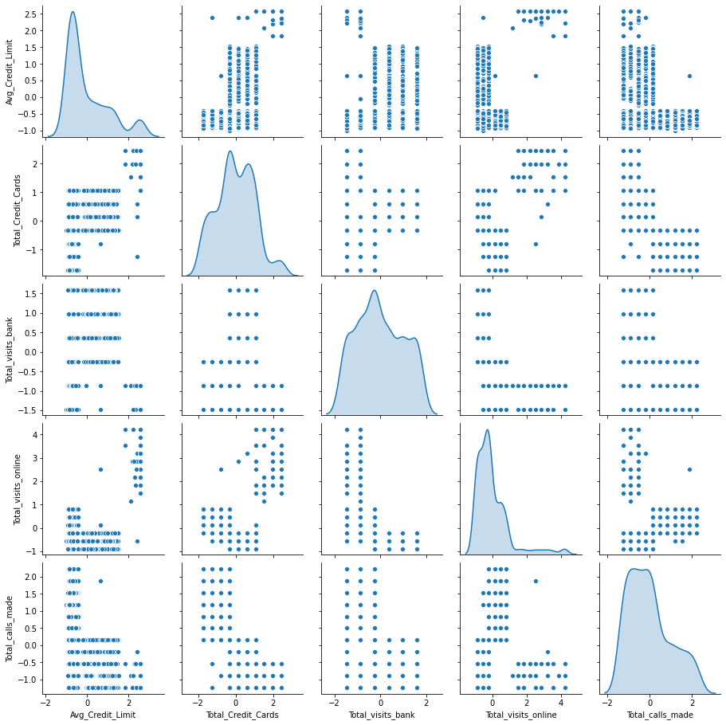

```python
#Pairplot for bivariate analysis.
#Use diagonal univariate analysis to count the possible number of clusters for K means.
ccdata1=ccdata.iloc[:,2:]                      #Exclude the ID variables: Customer Key and SI_No
ccdatascaled=ccdata1.apply(zscore)             #For scaling. Make the mean = 0, and sd = 1
sns.pairplot(ccdatascaled,diag_kind='kde')     #Pairplot code, set the diagonal with kde.
```

To determine the number of minimum clusters, we have to focus on the diagnonal, which is basically a scaled version of the histogram/distplots with the superimposed kde plotted above. It seems that in evaluating total credit cards, the possible minimum number of clusters could be 4. This is only a possibility. There could definitely be more clusters due to the presence of these other variables/dimensions. We are only observing this using 1-2 dimensions. If we incorporated the other variables, there may be other cluster(s) that are not immediately obvious to the eye in the 2-dimensional space.

1. Execute K-means clustering use elbow plot and analyse clusters using boxplot (10 marks)

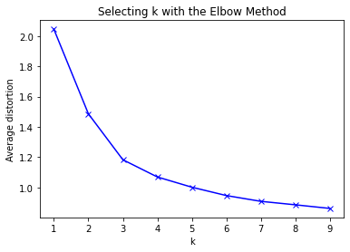

```python
#Finding optimal no. of clusters using the Elbow plot
from scipy.spatial.distance import cdist      #Used to calculate distances between points
clusters=range(1,10)
meanDistortions=[]

for k in clusters:
    model=KMeans(n_clusters=k)                # K Means
    model.fit(ccdatascaled)                   #Fit the model on scaled data
    prediction=model.predict(ccdatascaled)    # We will use the k means model to predict on the scaled data
    meanDistortions.append(sum(np.min(cdist(ccdatascaled, model.cluster_centers_, 'euclidean'), axis=1)) / ccdatascaled.shape[0])


plt.plot(clusters, meanDistortions, 'bx-')
plt.xlabel('k')
plt.ylabel('Average distortion')
plt.title('Selecting k with the Elbow Method')
```

The elbow plot is subjective, but can be a useful guide to determing a good number of clusters for k means clustering. It is advised to choose the k value where there is an "elbow" in the plot. This is when the within group sum of squares or variation shifts very little, when the line graph is becoming straighter and has the least amount of variance influence. In this case, it seems like when k = 3, the line graph begins to straighten out horizontally and most of the variation is already captured by 3 clusters. Adding a fourth cluster would not significantly add to explaining the variation of the data. Perhaps we should also explore k = 4, and examine their respective silhouette score.

1. Execute hierarchical clustering (with different linkages) with the help of dendrogram and cophenetic coeff. Analyse clusters formed using boxplot (15 marks)
2. Calculate average silhouette score for both methods. (5 marks)

PERFORMING K MEANS, EVALUATING K = 3

```python
# Let us first start with K = 3
final_model=KMeans(3)
final_model.fit(ccdatascaled)
prediction=final_model.predict(ccdatascaled)

#Append the prediction and create a variable called "GROUP", which are the different clusters, for the regular data and the scaled data.
ccdata1["GROUP"] = prediction
ccdatascaled["GROUP"] = prediction
print("Groups Assigned : \n")
ccdata1.head()
```

```
Groups Assigned :
```

|  | Avg_Credit_Limit | Total_Credit_Cards | Total_visits_bank | Total_visits_online | Total_calls_made | GROUP |
| --- | --- | --- | --- | --- | --- | --- |
| 0 | 100000 | 2 | 1 | 1 | 0 | 0 |
| 1 | 50000 | 3 | 0 | 10 | 9 | 1 |
| 2 | 50000 | 7 | 1 | 3 | 4 | 0 |
| 3 | 30000 | 5 | 1 | 1 | 4 | 0 |
| 4 | 100000 | 6 | 0 | 12 | 3 | 2 |

The 3 group/cluster numbers are: 0, 1, and 2.

```python
##Calculating the means of every variable in the unscaled data and organizing it by cluster using groupby

ccdataclust = ccdata1.groupby(['GROUP'])
ccdataclust.mean()
```

| GROUP | Avg_Credit_Limit | Total_Credit_Cards | Total_visits_bank | Total_visits_online | Total_calls_made |
| --- | --- | --- | --- | --- | --- |
| 0 | 33782.383420 | 5.515544 | 3.489637 | 0.981865 | 2.000000 |
| 1 | 12174.107143 | 2.410714 | 0.933036 | 3.553571 | 6.870536 |
| 2 | 102660.000000 | 8.740000 | 0.600000 | 10.900000 | 1.080000 |

Those that are have higher average of average credit limit have a higher average of credit cards and tend to bank online more frequently. Those who are of the middle tier in terms of average credit limit are more likely to visit and/or call the bank than they are to engage in online banking.

```
array([[<matplotlib.axes._subplots.AxesSubplot object at 0x000002AB30ABE940>,
      dtype=object)
```

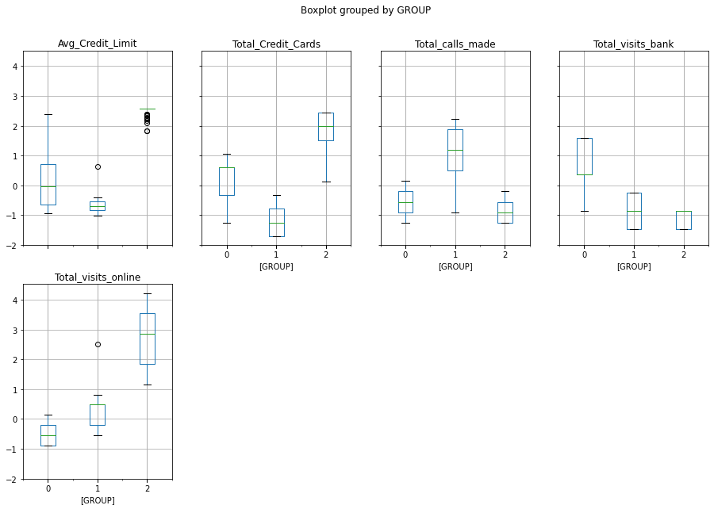

```python
#Observe the boxplots for the scaled data and visualize if k means clustering is a good segmentation method for this data.

ccdatascaled.boxplot(by='GROUP', layout = (2,4),figsize=(15,10))
```

Additional statistical method to determine independence between clusters: Visually, these boxplots show much overlap when the data is segmented into 3 clusters (k = 3). One method to ascertain statistically significant overlap is to use a statistical test like ANOVA, if you want to see if all 3 clusters are independent of one another when it comes to these 5 variables. The only downside of ANOVA would be that it can only tell if at least 1 cluster is not indpendent of another cluster. It won't tell which cluster is independent or not independent.

Another observation is that there are outliers in particular clusters for certain variables, such as Group 1 and Group 2 in Avg_Credit_Limit and Group 1 in Total_visits_online. These outliers were not present in the original dataset after we handled the outliers for Avg_Credit_Limit. The reason for these is because in K means the centroids are randomly inserted into the multi-dimensional space among the observations. These distances between each observation and the centroids are subject to change depending on where the centroid is randomly placed.

However, calculating the silhouette score is a metric that is also effective for k means clustering analysis.

```python
#Calculate silhouette score
from sklearn.metrics import silhouette_score
k_means_3_score = silhouette_score(ccdatascaled, final_model.labels_, metric='euclidean')
print('Silhouette Score: %.3f' % k_means_3_score)
```

```
Silhouette Score: 0.532
```

```python
#Make a dataframe with this information so that we can merge this into a big table and compare this measure to the others.

silhouette_score_K_Means_3 ={'Metric':['Silhouette Score'], 'K Means(3 Clusters)':[k_means_3_score]}
dataframe1 = pd.DataFrame(silhouette_score_K_Means_3)
dataframe1
```

|  | Metric | K Means(3 Clusters) |
| --- | --- | --- |
| 0 | Silhouette Score | 0.532248 |

The silhouette score can determine how separated are the clusters. It measures the average of how similar observations in multi-dimensional space are to their own cluster compared to other neighboring clusters.

The silhouette score ranges from -1 to 1. 1 means that the average of all points are closer to their respective cluster than the neighboring cluster(s). -1 means that the average of all points are closer to their neighboring clusters compared to their designated cluster.

For k = 3, the Silhouette score is 0.53, which is decent. Anything well above 0.5 is considered good.

EVALUATING K = 4

```python
# Let's now try K = 4
final_model=KMeans(4)
final_model.fit(ccdatascaled)
prediction=final_model.predict(ccdatascaled)

#Append the prediction to the original data and the scaled data.
ccdata1["GROUP"] = prediction
ccdatascaled["GROUP"] = prediction
print("Groups Assigned : \n")
ccdata1.head()                   #Making sure the new GROUP variable is appended.
```

```
Groups Assigned :
```

|  | Avg_Credit_Limit | Total_Credit_Cards | Total_visits_bank | Total_visits_online | Total_calls_made | GROUP |
| --- | --- | --- | --- | --- | --- | --- |
| 0 | 100000 | 2 | 1 | 1 | 0 | 3 |
| 1 | 50000 | 3 | 0 | 10 | 9 | 2 |
| 2 | 50000 | 7 | 1 | 3 | 4 | 3 |
| 3 | 30000 | 5 | 1 | 1 | 4 | 3 |
| 4 | 100000 | 6 | 0 | 12 | 3 | 0 |

```python
#Calculating the means of every variable in the unscaled data and organizing it by cluster using groupby

ccdataclust4 = ccdata1.groupby(['GROUP'])
ccdataclust4.mean()
```

| GROUP | Avg_Credit_Limit | Total_Credit_Cards | Total_visits_bank | Total_visits_online | Total_calls_made |
| --- | --- | --- | --- | --- | --- |
| 0 | 102660.000000 | 8.740000 | 0.600000 | 10.900000 | 1.080000 |
| 1 | 17266.968326 | 5.502262 | 3.719457 | 1.009050 | 1.923077 |
| 2 | 12174.107143 | 2.410714 | 0.933036 | 3.553571 | 6.870536 |
| 3 | 55903.030303 | 5.533333 | 3.181818 | 0.945455 | 2.103030 |

For 4 clusters, the group with the highest average credit limit are still most active online. There is a middle group that still favors bank visits and telephone banking calls. However, there are 2 clusters that have the lowest average credit limit. Cluster 2 is more similar to the lower tier group in the 3 clusters analysis. Group 1 is very different, as these individuals have a preference for total banks visits compared to all other means

```
array([[<matplotlib.axes._subplots.AxesSubplot object at 0x000002AB33940580>,
      dtype=object)
```

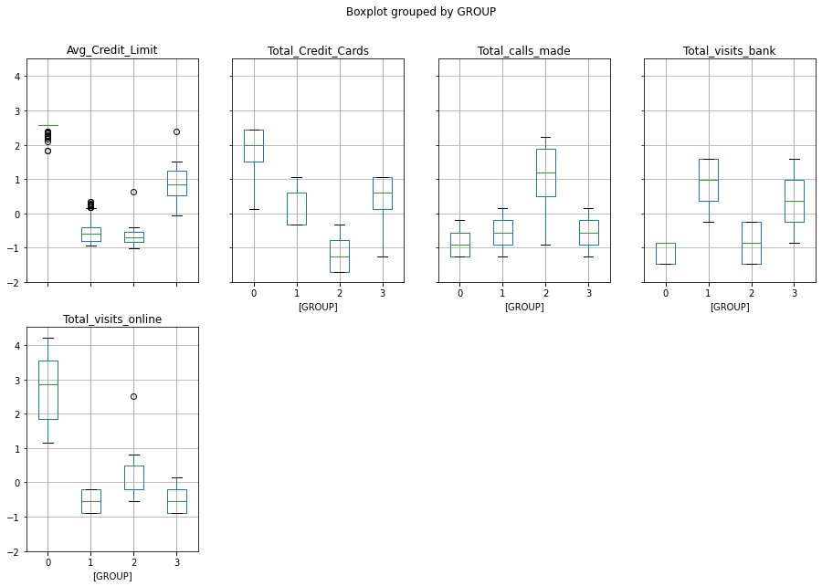

```python
#Boxplots to show clustering with k = 4

ccdatascaled.boxplot(by='GROUP', layout = (2,4),figsize=(15,10))
```

Looking at these boxplots, there seems to be a lot more overlap between the clusters here than when k = 3. We could potentially see a decrease in the silhouette score. Like what was mentioned before, the presence of outliers are attributed where the centroids are located in reference to the observations.

```python
#Calculating silhouette score for k = 4
from sklearn.metrics import silhouette_score
k_means_4_score = silhouette_score(ccdatascaled, final_model.labels_, metric='euclidean')
print('Silhouette Score: %.3f' % k_means_4_score)
```

```
Silhouette Score: 0.521
```

```python
#Make a dataframe with this information so that we can merge this into a big table and compare this measure to the others.

silhouette_score_K_Means_4 ={'Metric':['Silhouette Score'], 'K Means(4 Clusters)':[k_means_4_score]}
dataframe2 = pd.DataFrame(silhouette_score_K_Means_4)
dataframe2
```

|  | Metric | K Means(4 Clusters) |
| --- | --- | --- |
| 0 | Silhouette Score | 0.521261 |

HIERARCHICAL CLUSTERING:

```python
#In order to not confuse ourselves, let us create a new dataframe that eliminates the GROUP variable formed from K means before we attempt hierarchical clustering

print("Unscaled data as it is now")
print(ccdata1.head())                #Unscaled data as it is now
print("")
print("Scaled data as it is now")
print(ccdatascaled.head())           #Scaled data as it is now
print("")

#Create new dataframe with removed GROUP feature/variable
ccdata2=ccdata1.iloc[:,:5]
ccdatascaled2=ccdatascaled.iloc[:,:5]



#Viewing the unscaled and scaled dataframes for hierarchical clustering
print("New unscaled dataframe with dropped GROUP variable/feature")
print(ccdata2.head())
print("")
print("New scaled dataframe with dropped GROUP variable/feature")
ccdatascaled2.head()
```

[output not shown]

|  | Avg_Credit_Limit | Total_Credit_Cards | Total_visits_bank | Total_visits_online | Total_calls_made |
| --- | --- | --- | --- | --- | --- |
| 0 | 2.398942 | -1.249225 | -0.860451 | -0.547490 | -1.251537 |
| 1 | 0.643619 | -0.787585 | -1.473731 | 2.520519 | 1.891859 |
| 2 | 0.643619 | 1.058973 | -0.860451 | 0.134290 | 0.145528 |
| 3 | -0.058511 | 0.135694 | -0.860451 | -0.547490 | 0.145528 |
| 4 | 2.398942 | 0.597334 | -1.473731 | 3.202298 | -0.203739 |

```python
#Let's use the agglomerative clustering technique

from sklearn.cluster import AgglomerativeClustering
```

HIERARCHICAL CLUSTERING USING AVERAGE LINKAGE METHOD FOR 3 CLUSTERS

```python
#We can use the average linkage method and then fit it to the scaled data.
model = AgglomerativeClustering(n_clusters=3, affinity='euclidean',  linkage='average')
model.fit(ccdatascaled2)
```

```
AgglomerativeClustering(linkage='average', n_clusters=3)
```

```python
#We can also append these as labels to the unscaled and scaled data, like what we did previously when we discussed K means.
ccdata2['labels'] = model.labels_
ccdatascaled2['labels'] = model.labels_
```

```python
#Checking to see if the labels are appended to the scaled data. We need this to make the boxplots.
ccdatascaled2.head()
```

|  | Avg_Credit_Limit | Total_Credit_Cards | Total_visits_bank | Total_visits_online | Total_calls_made | labels |
| --- | --- | --- | --- | --- | --- | --- |
| 0 | 2.398942 | -1.249225 | -0.860451 | -0.547490 | -1.251537 | 2 |
| 1 | 0.643619 | -0.787585 | -1.473731 | 2.520519 | 1.891859 | 0 |
| 2 | 0.643619 | 1.058973 | -0.860451 | 0.134290 | 0.145528 | 0 |
| 3 | -0.058511 | 0.135694 | -0.860451 | -0.547490 | 0.145528 | 0 |
| 4 | 2.398942 | 0.597334 | -1.473731 | 3.202298 | -0.203739 | 1 |

```
array([[<matplotlib.axes._subplots.AxesSubplot object at 0x000002AB342E6D60>,
      dtype=object)
```

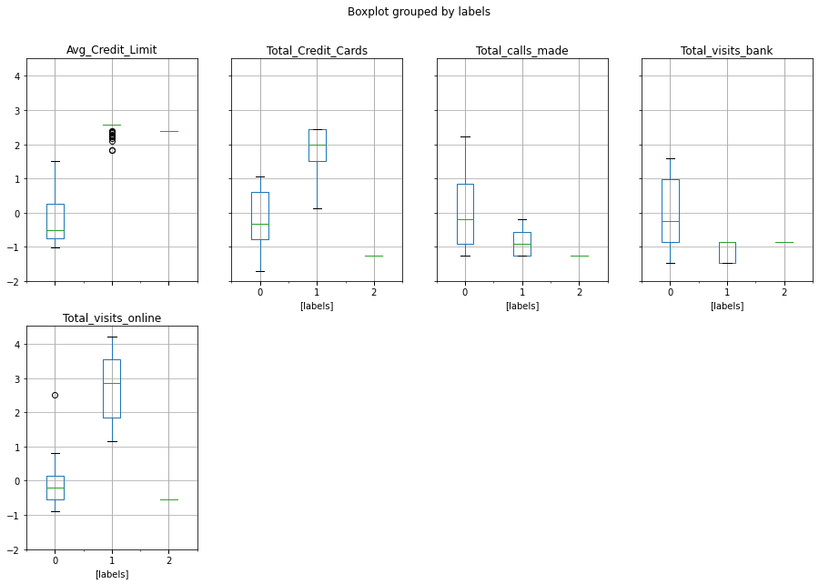

```python
#Boxplots to show hierarchical clustering by label (3 clusters) using average link

ccdatascaled2.boxplot(by='labels', layout = (2,4),figsize=(15,10))
```

There is still a lot of overlap between the different clusters, which suggests that these clusters may not be entirely separated from each other. Like previously, there are some new outliers but these as a result of the hierarchical clustering.

```python
#We can evaluate all the means according to each feature by label/cluster.

ccdatacluster.mean()
```

[output not shown]

```python
#Import libraries to calculate the cophenetic coefficient, to create the dendogram with different linkages

from scipy.cluster.hierarchy import cophenet, dendrogram, linkage
from scipy.spatial.distance import pdist                # This is for pairwise distribution between data points
```

```python
# calculating cophenetic coefficient
# cophenet index is a measure of the correlation between the distance of points in feature space and distance on dendrogram
# closer it is to 1, the better is the clustering

Z = linkage(ccdatascaled2, metric='euclidean', method='average')
c, coph_dists = cophenet(Z , pdist(ccdatascaled2))

c
```

```
0.8936260063525493
```